# Lab 7 - So what if you smoke when pregnant?

Simulation based inference

In 2004, the state of North Carolina released a large data set containing information on births recorded in this state. This data set is useful to researchers studying the relation between habits and practices of expectant mothers and the birth of their children. We will work with a random sample of observations from this data set.

# Packages

In this lab we will work with the `tidyverse`, `infer`, and `openintro` packages. We can install and load them with the following:

```r
library(tidyverse)
library(infer)
library(openintro)
```

# Housekeeping

## Project name:

Update the name of your project to match the lab’s title.

# Set a seed!

In this lab we’ll be generating random samples. The last thing you want is those samples to change every time you knit your document. So, you should set a seed. There’s an R chunk below for this. Locate it and set the seed.

```r
set.seed(154)
```

# The data

Load the `ncbirths` data from the `openintro` package:

```r
data(ncbirths)
```

We have observations on 13 different variables, some categorical and some numerical. The meaning of each variable is as follows.

| variable | description |
| --- | --- |
| `fage` | father’s age in years. |
| `mage` | mother’s age in years. |
| `mature` | maturity status of mother. |
| `weeks` | length of pregnancy in weeks. |
| `premie` | whether the birth was classified as premature (premie) or full-term. |
| `visits` | number of hospital visits during pregnancy. |
| `marital` | whether mother is `married` or `not married` at birth. |
| `gained` | weight gained by mother during pregnancy in pounds. |
| `weight` | weight of the baby at birth in pounds. |
| `lowbirthweight` | whether baby was classified as low birthweight (`low`) or not (`not low`). |
| `gender` | gender of the baby, `female` or `male`. |
| `habit` | status of the mother as a `nonsmoker` or a `smoker`. |
| `whitemom` | whether mom is `white` or `not white`. |

1. What are the cases in this data set? How many cases are there in our sample?

```r
glimpse(ncbirths)
```

```
## Observations: 1,000
## Variables: 13
## $ fage           <int> NA, NA, 19, 21, NA, NA, 18, 17, NA, 20, 30, NA, NA, ...
## $ mage           <int> 13, 14, 15, 15, 15, 15, 15, 15, 16, 16, 16, 16, 16, ...
## $ mature         <fct> younger mom, younger mom, younger mom, younger mom, ...
## $ weeks          <int> 39, 42, 37, 41, 39, 38, 37, 35, 38, 37, 45, 42, 40, ...
## $ premie         <fct> full term, full term, full term, full term, full ter...
## $ visits         <int> 10, 15, 11, 6, 9, 19, 12, 5, 9, 13, 9, 8, 4, 12, 15,...
## $ marital        <fct> married, married, married, married, married, married...
## $ gained         <int> 38, 20, 38, 34, 27, 22, 76, 15, NA, 52, 28, 34, 12, ...
## $ weight         <dbl> 7.6, 7.9, 6.6, 8.0, 6.4, 5.4, 8.4, 4.7, 8.8, 6.9, 7....
## $ lowbirthweight <fct> not low, not low, not low, not low, not low, low, no...
## $ gender         <fct> male, male, female, male, female, male, male, male, ...
## $ habit          <fct> nonsmoker, nonsmoker, nonsmoker, nonsmoker, nonsmoke...
## $ whitemom       <fct> not white, not white, white, white, not white, not w...
```

```r
# cases are births
# 1000 cases
summary(ncbirths)
```

```
##       fage          mage            mature        weeks          premie
##  Min.   :14    Min.   :13   mature mom :133   Min.   :20   full term:846
##  1st Qu.:25    1st Qu.:22   younger mom:867   1st Qu.:37   premie   :152
##  Median :30    Median :27                     Median :39   NA's     :  2
##  Mean   :30    Mean   :27                     Mean   :38
##  3rd Qu.:35    3rd Qu.:32                     3rd Qu.:40
##  Max.   :55    Max.   :50                     Max.   :45
##  NA's   :171                                  NA's   :2
##      visits            marital        gained       weight     lowbirthweight
##  Min.   : 0.0   married    :386   Min.   : 0   Min.   : 1.0   low    :111
##  1st Qu.:10.0   not married:613   1st Qu.:20   1st Qu.: 6.4   not low:889
##  Median :12.0   NA's       :  1   Median :30   Median : 7.3
##  Mean   :12.1                     Mean   :30   Mean   : 7.1
##  3rd Qu.:15.0                     3rd Qu.:38   3rd Qu.: 8.1
##  Max.   :30.0                     Max.   :85   Max.   :11.8
##  NA's   :9                        NA's   :27
##     gender          habit          whitemom
##  female:503   nonsmoker:873   not white:284
##  male  :497   smoker   :126   white    :714
##               NA's     :  1   NA's     :  2
##
##
##
##
```

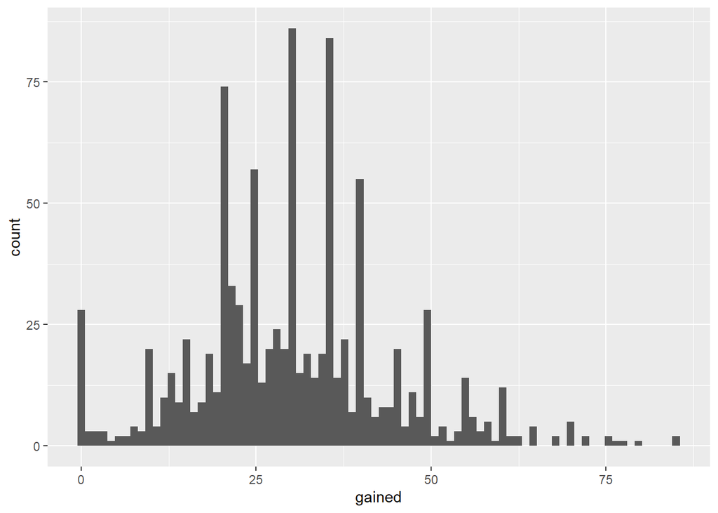

```r
ncbirths %>%
  filter(!is.na(gained)) %>%
  ggplot(aes(x = gained)) +
  geom_histogram(bins = 80)
```

The first step in the analysis of a new dataset is getting acquanted with the data. Make summaries of the variables in your dataset, determine which variables are categorical and which are numerical. For numerical variables, are there outliers? If you aren’t sure or want to take a closer look at the data, make a graph.